Volver al inicio

# Unidad 2. Análisis y representación de datos numéricos

Veremos los análisis a realizar para procesar variables continuas (correlación y regresión) y como representarlas gráficamente de una forma más detallada que como lo vimos hasta ahora.

## Correlación

Cuando queremos evaluar la relación entre 2 variables continuas, sin establecer relaciones de dependencia, el análisis que debemos hacer es un análisis de correlación lineal. El test de correlación lineal más utilizado es el de correlación de Pearson, que nos arroja el coeficiente de Pearson, que toma valores entre -1 y 1, según la relación sea inversa o directa. Valores cercanos a cero indican falta de relación entre las variables. La correlación de Pearson tiene como supuestos la distribución normal de las variables (entre otros). Debemos poner a prueba esos supuestos para poder realizar este tipo de análisis.

Comenzaremos creando una base de datos de las semillas:

```r
SEM <- metales %>% filter(Organo == "Semilla")
```

Veremos primero como analizar de a pares de variables. Lo recomendable es iniciar con una exploración gráfica de los datos, en este caso vamos a relacionar la acumulación de Cu y Zn en semillas.

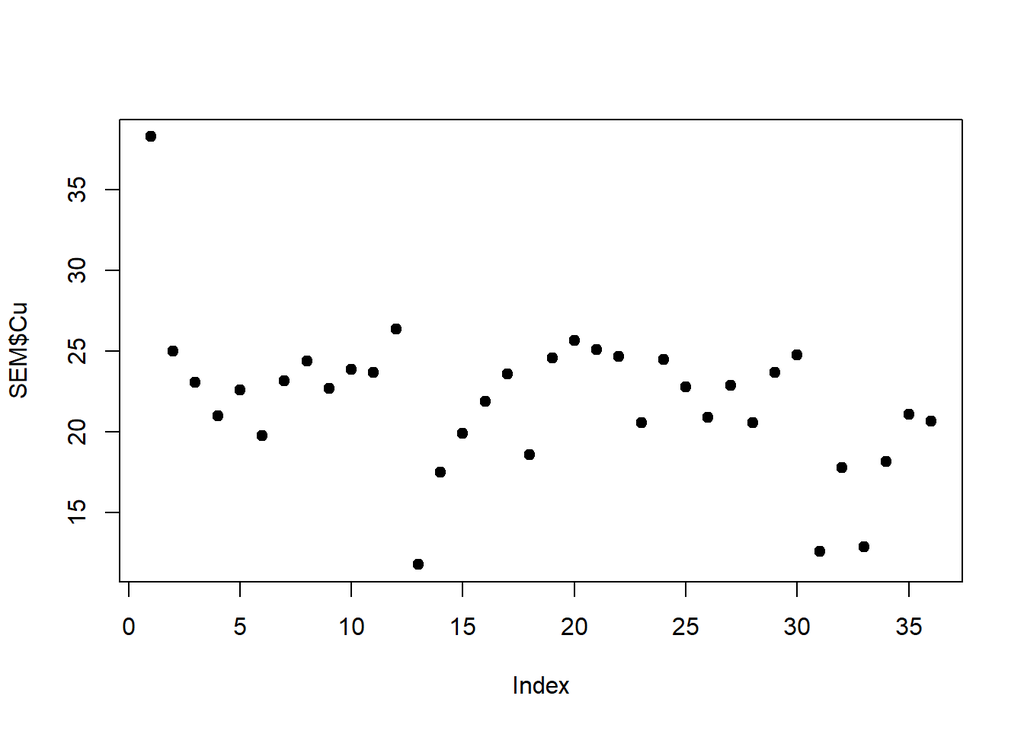

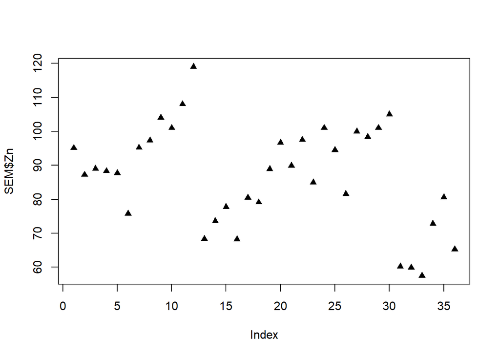

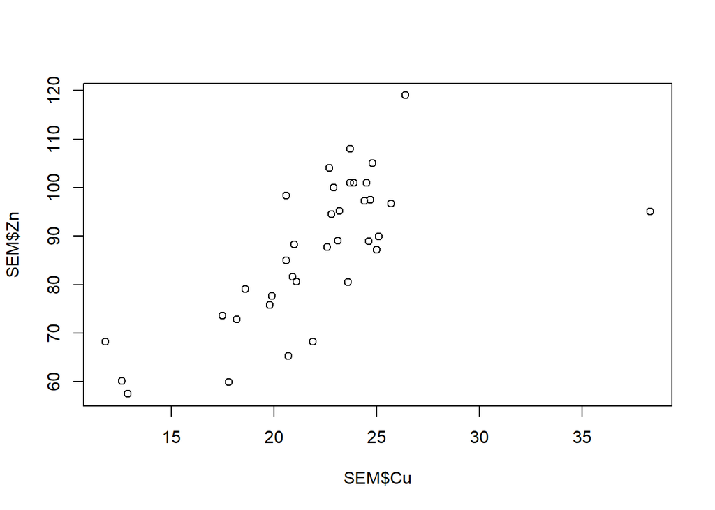

```r
# Exploración gráfica

plot(SEM$Cu, pch = 19)
plot(SEM$Zn, pch = 17)
plot(SEM$Cu, SEM$Zn)
```

Vemos que hay un valor extremo en el gráfico de Cu, para identificarlo podemos correr *identify*:

```r
plot(SEM$Cu)
identify(SEM$Cu)
```

Ahora veremos cómo hacer la correlación de pearson, de momento ignorando los supuestos:

```r
cor.test(SEM$Cu, SEM$Zn, method = "pearson")
```

```
##
##  Pearson's product-moment correlation
##
## data:  SEM$Cu and SEM$Zn
## t = 5.4405, df = 34, p-value = 4.599e-06
## alternative hypothesis: true correlation is not equal to 0
## 95 percent confidence interval:
##  0.4558295 0.8256796
## sample estimates:
##       cor
## 0.6822013
```

Vemos que nos arroja los resultados del valor del coeficiente lineal de pearson y su valor p asociado.